# CP06_2_Cointegración_BMW/VOW

FRANCISCO DEL VAL

13/12/2020

### Objetivo

Se pretende responder si existe o no, cointegración entre las acciones de BMW y VOLKSWAGEN.

### Análisis

En primer lugar, se realizarán los diferentes test de Dickey Fuller y Dickey Fuller Aumentado, para poder observar si la serie es estacionario o no.

Seguidamente, se realizará pruebas de cointegrción con el objetivos de practicar una regresión lineal y los erroes sean estacionrios de orden 0, I(0).

Por último, se realizará la correción de residuos para verificar si estan o no cointegrados entre si.

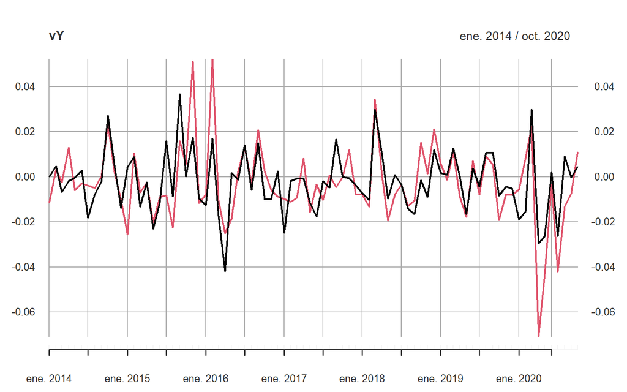

```
##
##  Augmented Dickey-Fuller Test
##
## data:  vY$BMW
## Dickey-Fuller = -4.9151, Lag order = 4, p-value = 0.01
## alternative hypothesis: stationary
```

```
##
##  Augmented Dickey-Fuller Test
##
## data:  vY$VOW
## Dickey-Fuller = -4.081, Lag order = 4, p-value = 0.01004
## alternative hypothesis: stationary
```

Como se pude observar, se rechaza la hipótesis nula ya que p-value < 0.05 y se afirma que ambas series son estacionarias.

```
##      Index        residuals
##  Min.   :2014   Min.   :-0.0273841
##  1st Qu.:2016   1st Qu.:-0.0059969
##  Median :2017   Median :-0.0001417
##  Mean   :2017   Mean   : 0.0000000
##  3rd Qu.:2019   3rd Qu.: 0.0049805
##  Max.   :2021   Max.   : 0.0284350
```

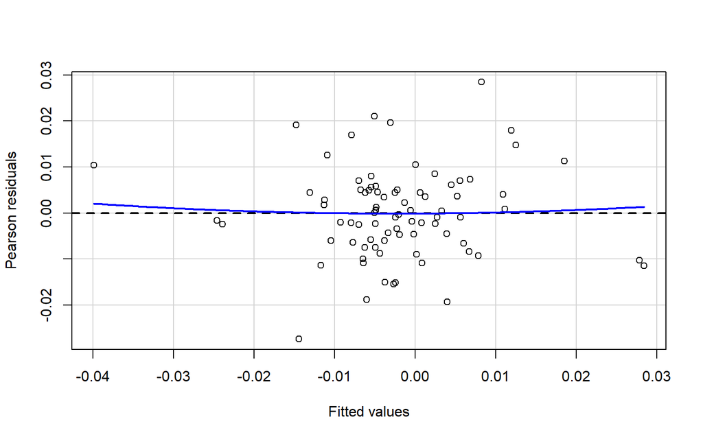

Los errores estan alrededor de la media lo que implica que las variables BMW y Volkswagen estan cointegradas.

```
##
##  Augmented Dickey-Fuller Test
##
## data:  residuals
## Dickey-Fuller = -4.5536, Lag order = 4, p-value = 0.01
## alternative hypothesis: stationary
```

```
##
## ###############################################
## # Augmented Dickey-Fuller Test Unit Root Test #
## ###############################################
##
## Test regression trend
##
##
## Call:
## lm(formula = z.diff ~ z.lag.1 + 1 + tt + z.diff.lag)
##
## Residuals:
##        Min         1Q     Median         3Q        Max
## -0.0265586 -0.0056576 -0.0003682  0.0048600  0.0256262
##
## Coefficients:
##               Estimate Std. Error t value Pr(>|t|)
## (Intercept) -1.969e-03  2.901e-03  -0.679   0.4997
## z.lag.1     -1.208e+00  2.293e-01  -5.267 1.68e-06 ***
## tt           4.085e-05  5.765e-05   0.709   0.4811
## z.diff.lag1  2.335e-01  1.992e-01   1.172   0.2453
## z.diff.lag2  2.742e-01  1.661e-01   1.650   0.1037
## z.diff.lag3  2.538e-01  1.201e-01   2.114   0.0384 *
## ---
## Signif. codes:  0 '***' 0.001 '**' 0.01 '*' 0.05 '.' 0.1 ' ' 1
##
## Residual standard error: 0.009921 on 65 degrees of freedom
## Multiple R-squared:  0.5177, Adjusted R-squared:  0.4806
## F-statistic: 13.95 on 5 and 65 DF,  p-value: 2.924e-09
##
##
## Value of test-statistic is: -5.2673 9.3109 13.964
##
## Critical values for test statistics:
##       1pct  5pct 10pct
## tau3 -4.04 -3.45 -3.15
## phi2  6.50  4.88  4.16
## phi3  8.73  6.49  5.47
```

Confirmamos con el test de Dickey Fuller con un p-value <0.05 los residuos son estacionarios.